# EasyVisa Project

### Hypertuning: AdaBoost (Boosting)

```python
# Tuning with AdaBoost
estimator_adaboost = AdaBoostClassifier(random_state=1)

# Grid of recommended tuning parameters
parameter_grid_ab = {
    'n_estimators': np.arange(50,110,25),
    'learning_rate': [0.01,0.1,0.05],
    'base_estimator': [
        DecisionTreeClassifier(max_depth=2, random_state=1),
        DecisionTreeClassifier(max_depth=3, random_state=1),
    ],
  }

# Type of scoring used to compare parameter combinations
scorer_ab = metrics.make_scorer(metrics.f1_score)

# Run the randomized search to help with computational issues
grid_obj_adaboost = GridSearchCV(
      estimator_adaboost,
      parameter_grid_ab,
      scoring=scorer_ab
      )

# Fit the model to the data
grid_obj_adaboost = grid_obj_adaboost.fit(X_train, y_train)

# Set the clf to the best combination of parameters
tuned_model_adaboost = grid_obj_adaboost.best_estimator_

# Fit the model to the data using best estimator
tuned_model_adaboost.fit(X_train, y_train)
```

```
AdaBoostClassifier(base_estimator=DecisionTreeClassifier(max_depth=3,
                                                         random_state=1),
                   learning_rate=0.1, random_state=1)
```

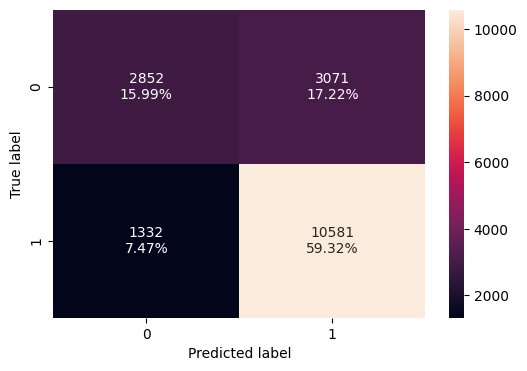

```python
confusion_matrix_sklearn(tuned_model_adaboost, X_train, y_train)
```

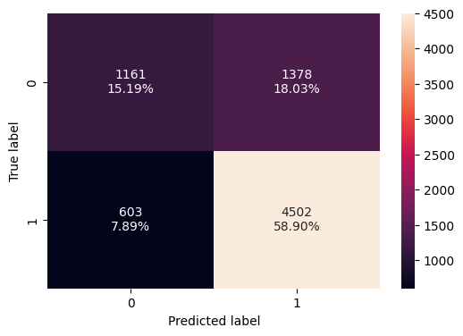

```python
confusion_matrix_sklearn(tuned_model_adaboost, X_test, y_test)
```

```python
tuned_model_adaboost_train_perf = model_performance_classification_sklearn(tuned_model_adaboost, X_train, y_train)
print('Training performance \n', tuned_model_adaboost_train_perf)
```

```
Training performance
    Accuracy    Recall  Precision        F1
0   0.75314  0.888189   0.775051  0.827772
```

```python
tuned_model_adaboost_test_perf = model_performance_classification_sklearn(tuned_model_adaboost, X_test, y_test)
print('Test performance \n', tuned_model_adaboost_test_perf)
```

```
Test performance
    Accuracy    Recall  Precision        F1
0  0.740842  0.881881   0.765646  0.819663
```

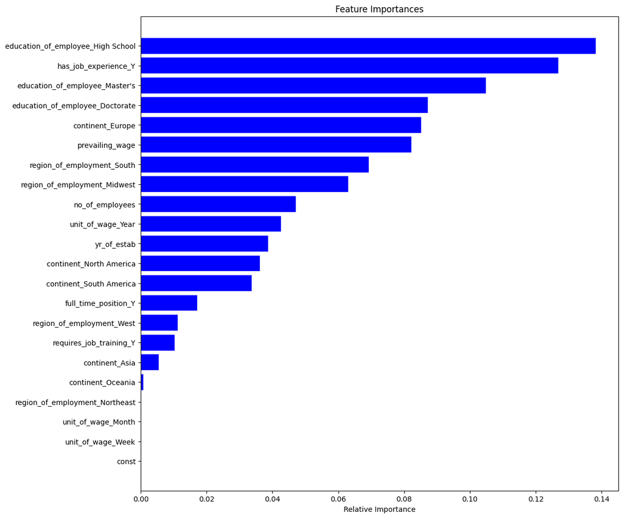

```python
# Check feature importance - AdaBoost - Visualization
importances_ada = tuned_model_adaboost.feature_importances_
indices_ada = np.argsort(importances_ada)

plt.figure(figsize=(12,12))
plt.title('Feature Importances')
plt.barh(range(len(indices_ada)), importances_ada[indices_ada], color='blue', align='center')
plt.yticks(range(len(indices_ada)), [feature_names[i] for i in indices_ada])
plt.xlabel('Relative Importance')
plt.show()
```

### Hypertuning: XGBoost (Boosting)

```python
# Tuning XGBoost
estimator_xgboost = XGBClassifier(random_state=1, eval_metric='logloss')

# Grid of recommended tuning parameters
parameter_grid_xgb = {
      'n_estimators':np.arange(50,110,25),
      'scale_pos_weight':[1,2,5],
      'learning_rate':[0.01,0.1,0.05],
      'gamma':[1,3],
      'subsample':[0.7,0.9]
  }

# Type of scoring used to compare parameter combinations
scorer_xgb = metrics.make_scorer(metrics.f1_score)

# Run the Grid CV search
grid_obj_xgboost = GridSearchCV(
      estimator_xgboost,
      parameter_grid_xgb,
      scoring=scorer_xgb
      )

# Fit the model to the data
grid_obj_xgboost = grid_obj_xgboost.fit(X_train, y_train)

# Set the model to the best combination of parameters
tuned_model_xgboost = grid_obj_xgboost.best_estimator_

# Fit the model to the data using best estimator
tuned_model_xgboost.fit(X_train, y_train)
```

```
XGBClassifier(base_score=None, booster=None, callbacks=None,
              colsample_bylevel=None, colsample_bynode=None,
              colsample_bytree=None, device=None, early_stopping_rounds=None,
              enable_categorical=False, eval_metric='logloss',
              feature_types=None, gamma=3, grow_policy=None,
              importance_type=None, interaction_constraints=None,
              learning_rate=0.05, max_bin=None, max_cat_threshold=None,
              max_cat_to_onehot=None, max_delta_step=None, max_depth=None,
              max_leaves=None, min_child_weight=None, missing=nan,
              monotone_constraints=None, multi_strategy=None, n_estimators=50,
              n_jobs=None, num_parallel_tree=None, random_state=1, ...)
```

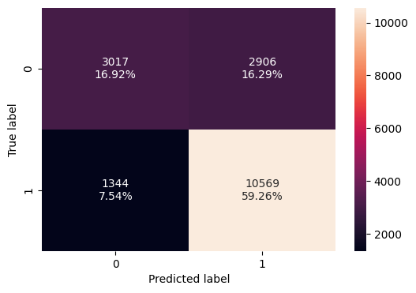

```python
confusion_matrix_sklearn(tuned_model_xgboost, X_train, y_train)
```

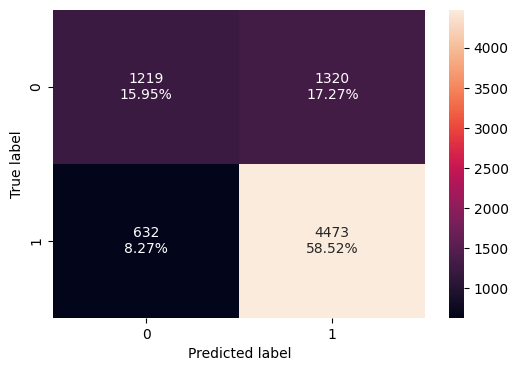

```python
confusion_matrix_sklearn(tuned_model_xgboost, X_test, y_test)
```

```python
tuned_model_xgboost_train_perf = model_performance_classification_sklearn(tuned_model_xgboost, X_train, y_train)
print('Training performance \n', tuned_model_xgboost_train_perf)
```

```
Training performance
    Accuracy    Recall  Precision        F1
0  0.761718  0.887182   0.784341  0.832598
```

```python
tuned_model_xgboost_test_perf = model_performance_classification_sklearn(tuned_model_xgboost, X_test, y_test)
print('Test performance \n', tuned_model_xgboost_test_perf)
```

```
Test performance
    Accuracy  Recall  Precision        F1
0  0.744636  0.8762   0.772139  0.820885
```

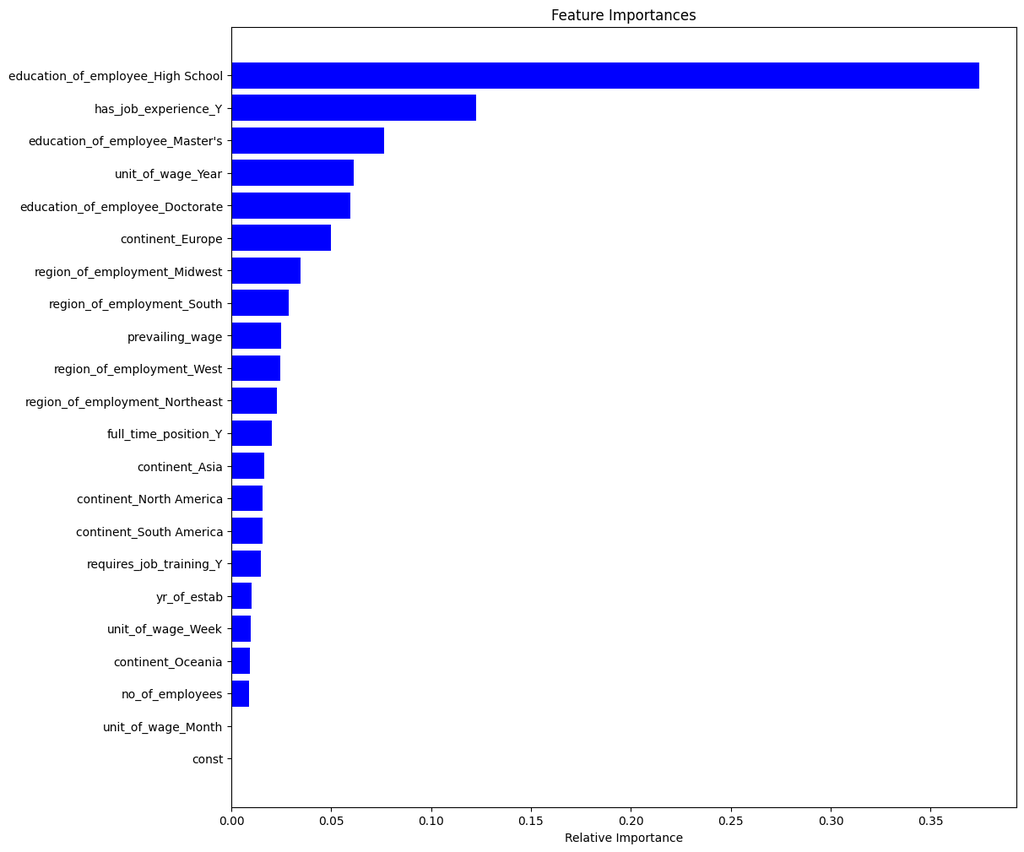

```python
# Check feature importance - XGBoost - Visualization
importances_xgb = tuned_model_xgboost.feature_importances_
indices_xgb = np.argsort(importances_xgb)

plt.figure(figsize=(12,12))
plt.title('Feature Importances')
plt.barh(range(len(indices_xgb)), importances_xgb[indices_xgb], color='blue', align='center')
plt.yticks(range(len(indices_xgb)), [feature_names[i] for i in indices_xgb])
plt.xlabel('Relative Importance')
plt.show()
```

### Hypertuning: Bagging

```python
# Tune bagging model
estimator_bagging = BaggingClassifier(random_state=1)

# Tune bagging model with an expansion, since original hyperparameters yielded disparate training and test results
estimator_expanded_bagging = BaggingClassifier(base_estimator=DecisionTreeClassifier(), random_state=1)

# Grid of recommended hypertuning parameters
parameter_grid_bag = {
    'max_samples': [0.8,0.9,1],
    'max_features': [0.7,0.8,0.9],
    'n_estimators' : [30,50,70],
}

# Grid of expanded hyperparameters to see if we can further tune the model
parameter_expanded_grid_bag = {
    'base_estimator__max_depth': [5],
    'max_samples': [0.7, 0.8, 0.9],
    'max_features': [0.7, 0.8, 0.9],
    'n_estimators': [30, 50, 70]
}

# Type of scoring used to compare parameter combinations
scorer_bag = metrics.make_scorer(metrics.f1_score)

# Run the grid search
grid_obj_bagging = GridSearchCV(
      estimator_expanded_bagging,  #estimator_bagging,
      parameter_expanded_grid_bag, #parameter_grid_bag,
      scoring=scorer_bag
      )

# Fit the model to the data
grid_obj_bagging = grid_obj_bagging.fit(X_train, y_train)

# Set the model to the best combination of parameters
tuned_model_bagging = grid_obj_bagging.best_estimator_

# Fit the model to the data using the best estimator
tuned_model_bagging.fit(X_train, y_train)
```

```
BaggingClassifier(base_estimator=DecisionTreeClassifier(max_depth=5),
                  max_features=0.8, max_samples=0.8, n_estimators=30,
                  random_state=1)
```

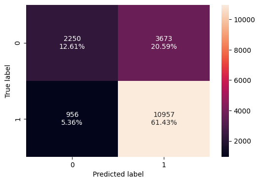

```python
confusion_matrix_sklearn(tuned_model_bagging, X_train, y_train)
```

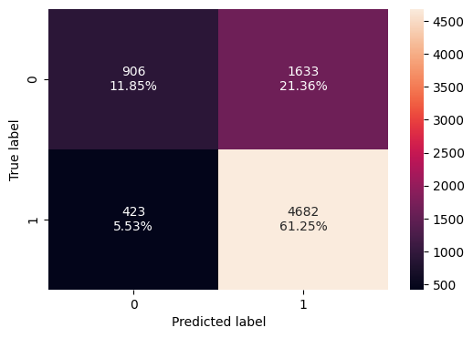

```python
confusion_matrix_sklearn(tuned_model_bagging, X_test, y_test)
```

```python
tuned_model_bagging_train_perf = model_performance_classification_sklearn(tuned_model_bagging, X_train, y_train)
print('Training performance \n', tuned_model_bagging_train_perf)
```

```
Training performance
    Accuracy    Recall  Precision        F1
0  0.740469  0.919752   0.748941  0.825604
```

```python
tuned_model_bagging_test_perf = model_performance_classification_sklearn(tuned_model_bagging, X_test, y_test)
print('Test performance \n', tuned_model_bagging_test_perf)
```

```
Test performance
    Accuracy   Recall  Precision        F1
0  0.731031  0.91714   0.741409  0.819965
```

## Model Performance Comparison

With these tuned results, we can include all of these learners in our final model, providing a diverse set of inputs into our ensemble model.

##### Model Metric Results

Let's collect the metric results and compare them.

```python
# Create a dataframe comparing the performance of the base models on the training data

models_train_compare = pd.concat(
    [model_decision_tree_train_perf.T,
     model_bagging_train_perf.T,
     model_random_forest_train_perf.T,
     model_adaboost_train_perf.T,
     model_gradient_boost_train_perf.T,
     model_xgboost_train_perf.T],
    axis=1,
)

models_train_compare.columns = [
    'Decision Tree',
    'Bagging',
    'Random Forest',
    'AdaBoost',
    'Gradient Boost',
    'XGBoost']
```

```python
# Create a dataframe comparing the performance of the base models on the testing data

models_test_compare = pd.concat(
    [model_decision_tree_test_perf.T,
     model_bagging_test_perf.T,
     model_random_forest_test_perf.T,
     model_adaboost_test_perf.T,
     model_gradient_boost_test_perf.T,
     model_xgboost_test_perf.T],
    axis=1,
)
models_test_compare.columns = [
    'Decision Tree',
    'Bagging',
    'Random Forest',
    'AdaBoost',
    'Gradient Boost',
    'XGBoost']
```

```python
# Create a dataframe comparing the performance of the tuned models on the training data
tuned_models_train_compare = pd.concat(
    [tuned_model_decision_tree_train_perf.T,
     tuned_model_bagging_train_perf.T,
     tuned_model_random_forest_train_perf.T,
     tuned_model_adaboost_train_perf.T,
     tuned_model_gradient_boost_train_perf.T,
     tuned_model_xgboost_train_perf.T],
    axis=1,
)

tuned_models_train_compare.columns = [
    'Decision Tree',
    'Bagging',
    'Random Forest',
    'AdaBoost',
    'Gradient Boost',
    'XGBoost']
```

```python
# Create a dataframe comparing the performance of the tuned models on the testing data

tuned_models_test_compare = pd.concat(
    [tuned_model_decision_tree_test_perf.T,
     tuned_model_bagging_test_perf.T,
     tuned_model_random_forest_test_perf.T,
     tuned_model_adaboost_test_perf.T,
     tuned_model_gradient_boost_test_perf.T,
     tuned_model_xgboost_test_perf.T],
    axis=1,
)
tuned_models_test_compare.columns = [
    'Decision Tree',
    'Bagging',
    'Random Forest',
    'AdaBoost',
    'Gradient Boost',
    'XGBoost']
```

```python
# Show the original models
print('Model performance comparison: Training')
display(models_train_compare.T)
print('Model performance comparison: Testing')
display(models_test_compare.T)
```

```
Model performance comparison: Training
```

|  | Accuracy | Recall | Precision | F1 |
| --- | --- | --- | --- | --- |
| Decision Tree | 1.000000 | 1.000000 | 1.000000 | 1.000000 |
| Bagging | 0.985367 | 0.986234 | 0.991812 | 0.989015 |
| Random Forest | 1.000000 | 1.000000 | 1.000000 | 1.000000 |
| AdaBoost | 0.738058 | 0.887434 | 0.760411 | 0.819027 |
| Gradient Boost | 0.759419 | 0.882901 | 0.784106 | 0.830576 |
| XGBoost | 0.843575 | 0.931084 | 0.849246 | 0.888284 |

```
Model performance comparison: Testing
```

|  | Accuracy | Recall | Precision | F1 |
| --- | --- | --- | --- | --- |
| Decision Tree | 0.652276 | 0.745544 | 0.736883 | 0.741188 |
| Bagging | 0.695578 | 0.768854 | 0.773856 | 0.771347 |
| Random Forest | 0.720042 | 0.831342 | 0.768423 | 0.798645 |
| AdaBoost | 0.732993 | 0.885015 | 0.756530 | 0.815744 |
| Gradient Boost | 0.744767 | 0.873457 | 0.773595 | 0.820499 |
| XGBoost | 0.728545 | 0.855044 | 0.765789 | 0.807959 |

**OBSERVATIONS**

- For our untuned models, we can observe that Decision Tree, Random Forest and Bagging are all overfitted.
- AdaBoost generalized well, and gave us nearly identical metrics for both training and test data.
- Gradient Boost gave similar performance as AdaBoost.
- XGBoost is not overfitted, but doesn't generalize as well, since it performed worse on test data than training data.

```python
# Show the tuned models
print('Tuned Model performance comparison: Training')
display(tuned_models_train_compare.T)
print('Tuned Model performance comparison: Testing')
display(tuned_models_test_compare.T)
```

```
Tuned Model performance comparison: Training
```

|  | Accuracy | Recall | Precision | F1 |
| --- | --- | --- | --- | --- |
| Decision Tree | 0.710193 | 0.725762 | 0.819681 | 0.769868 |
| Bagging | 0.740469 | 0.919752 | 0.748941 | 0.825604 |
| Random Forest | 0.786667 | 0.969529 | 0.770411 | 0.858576 |
| AdaBoost | 0.753140 | 0.888189 | 0.775051 | 0.827772 |
| Gradient Boost | 0.754710 | 0.885839 | 0.777786 | 0.828303 |
| XGBoost | 0.761718 | 0.887182 | 0.784341 | 0.832598 |

```
Tuned Model performance comparison: Testing
```

|  | Accuracy | Recall | Precision | F1 |
| --- | --- | --- | --- | --- |
| Decision Tree | 0.707483 | 0.726543 | 0.815344 | 0.768386 |
| Bagging | 0.731031 | 0.917140 | 0.741409 | 0.819965 |
| Random Forest | 0.724751 | 0.929285 | 0.731309 | 0.818496 |
| AdaBoost | 0.740842 | 0.881881 | 0.765646 | 0.819663 |
| Gradient Boost | 0.743328 | 0.880118 | 0.768954 | 0.820789 |
| XGBoost | 0.744636 | 0.876200 | 0.772139 | 0.820885 |